# hw2_1

Загружаем данные и применяем контраст для пола

```r
library(MASS)
library(lattice)
library(latticeExtra)
```

```r
panel <- function(...) {
  panel.xyplot(...)
  panel.loess(...)
}

teen.data <- read.table("teengambling.txt")

teen.data$sex <- factor(teen.data$sex, labels = c("male", "female"))

contrasts(teen.data$sex)
```

```
##        female
## male        0
## female      1
```

```r
contrasts(teen.data$sex) <- contr.sum
contrasts(teen.data$sex)
```

```
##        [,1]
## male      1
## female   -1
```

```r
model.teen1 <- lm(gamble ~ ., data=teen.data )
summary(model.teen1)
```

```
##
## Call:
## lm(formula = gamble ~ ., data = teen.data)
##
## Residuals:
##     Min      1Q  Median      3Q     Max
## -51.082 -11.320  -1.451   9.452  94.252
##
## Coefficients:
##             Estimate Std. Error t value Pr(>|t|)
## (Intercept) 11.49649   15.48722   0.742   0.4620
## sex1        11.05917    4.10556   2.694   0.0101 *
## status       0.05223    0.28111   0.186   0.8535
## income       4.96198    1.02539   4.839 1.79e-05 ***
## verbal      -2.95949    2.17215  -1.362   0.1803
## ---
## Signif. codes:  0 '***' 0.001 '**' 0.01 '*' 0.05 '.' 0.1 ' ' 1
##
## Residual standard error: 22.69 on 42 degrees of freedom
## Multiple R-squared:  0.5267, Adjusted R-squared:  0.4816
## F-statistic: 11.69 on 4 and 42 DF,  p-value: 1.815e-06
```

```r
model.teen1 <- stepAIC(model.teen1)
```

```
## Start:  AIC=298.18
## gamble ~ sex + status + income + verbal
##
##          Df Sum of Sq   RSS    AIC
## - status  1      17.8 21642 296.21
## <none>                21624 298.18
## - verbal  1     955.7 22580 298.21
## - sex     1    3735.8 25360 303.67
## - income  1   12056.2 33680 317.00
##
## Step:  AIC=296.21
## gamble ~ sex + income + verbal
##
##          Df Sum of Sq   RSS    AIC
## <none>                21642 296.21
## - verbal  1    1139.8 22781 296.63
## - sex     1    5787.9 27429 305.35
## - income  1   13236.1 34878 316.64
```

```r
summary(model.teen1)
```

```
##
## Call:
## lm(formula = gamble ~ sex + income + verbal, data = teen.data)
##
## Residuals:
##     Min      1Q  Median      3Q     Max
## -50.639 -11.765  -1.594   9.305  93.867
##
## Coefficients:
##             Estimate Std. Error t value Pr(>|t|)
## (Intercept)  12.6589    14.0076   0.904   0.3712
## sex1         11.4801     3.3853   3.391   0.0015 **
## income        4.8981     0.9551   5.128 6.64e-06 ***
## verbal       -2.7468     1.8253  -1.505   0.1397
## ---
## Signif. codes:  0 '***' 0.001 '**' 0.01 '*' 0.05 '.' 0.1 ' ' 1
##
## Residual standard error: 22.43 on 43 degrees of freedom
## Multiple R-squared:  0.5263, Adjusted R-squared:  0.4933
## F-statistic: 15.93 on 3 and 43 DF,  p-value: 4.148e-07
```

Видим, что adjusted R-squared повысился, а RSE уменьшился, значит модель стала лучше, но все равно его значение еще слишком мало, чтобы считать модель хорошей.

```r
model.teen2 <- lm(gamble ~ sex +  income, data=teen.data)
summary(model.teen2)
```

```
##
## Call:
## lm(formula = gamble ~ sex + income, data = teen.data)
##
## Residuals:
##     Min      1Q  Median      3Q     Max
## -49.757 -11.649   0.844   8.659 100.243
##
## Coefficients:
##             Estimate Std. Error t value Pr(>|t|)
## (Intercept)   -6.776      5.501  -1.232  0.22459
## sex1          10.817      3.404   3.177  0.00272 **
## income         5.172      0.951   5.438 2.24e-06 ***
## ---
## Signif. codes:  0 '***' 0.001 '**' 0.01 '*' 0.05 '.' 0.1 ' ' 1
##
## Residual standard error: 22.75 on 44 degrees of freedom
## Multiple R-squared:  0.5014, Adjusted R-squared:  0.4787
## F-statistic: 22.12 on 2 and 44 DF,  p-value: 2.243e-07
```

```r
anova(model.teen1, model.teen2)
```

```
## Analysis of Variance Table
##
## Model 1: gamble ~ sex + income + verbal
## Model 2: gamble ~ sex + income
##   Res.Df   RSS Df Sum of Sq      F Pr(>F)
## 1     43 21642
## 2     44 22781 -1   -1139.8 2.2646 0.1397
```

Значит при удалении verbal все же модель ухудшается, хотя p-value у verbal велико. В общем нужно посмотреть на однородность данных по полу, т.к. есть подозрение, что мы имеем какие-то не очень хорошие данные.

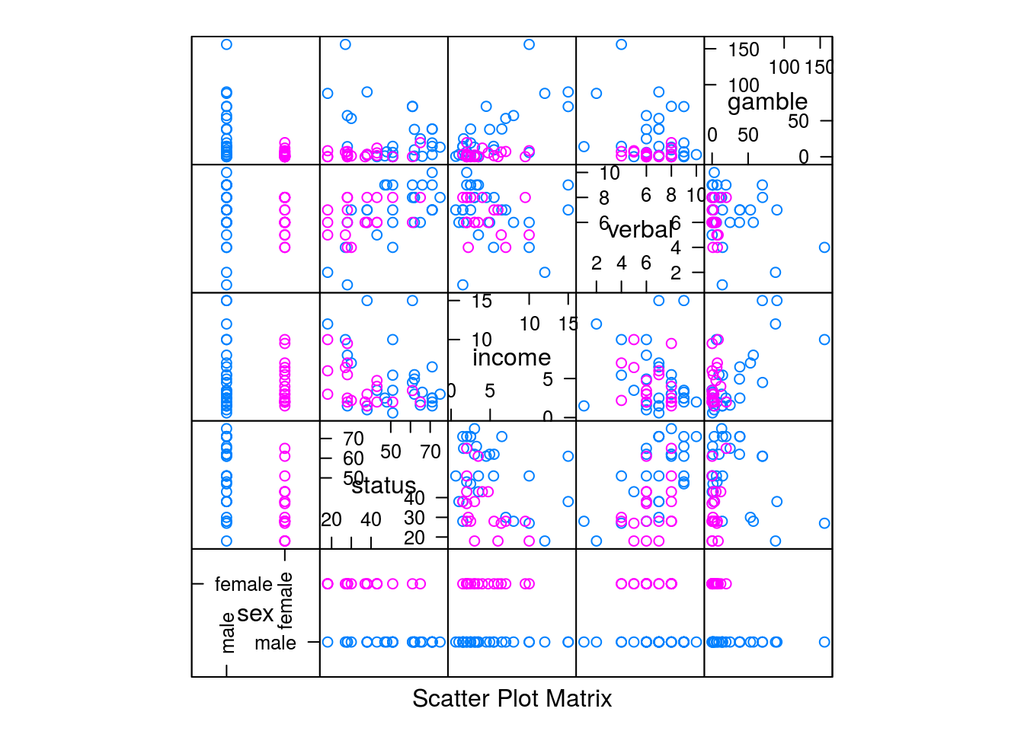

```r
splom(teen.data, groups=teen.data$sex)
```

Получили очень занятную картинку - данные неоднородны по полу. Особенно хорошо видна неоднородность в доходах, где чем больше доход, тем более неоднородны данные. Также мне совсем не нравится неоднородность verbal по полу - самые маленькие значения verbal у мальчиков выглядят, как выбросы. При этом они имеют высокое значение gamble, что может неблагоприятно влиять на общий результат. А вот в доходах неоднородность вполне логично смотрится и я думаю, что можно попробовать перекрестное влияние этих признаков.

```r
model.teen4 <- lm(gamble ~ income:sex  + verbal , data=teen.data)
summary(model.teen4)
```

```
##
## Call:
## lm(formula = gamble ~ income:sex + verbal, data = teen.data)
##
## Residuals:
##     Min      1Q  Median      3Q     Max
## -57.164  -6.121  -1.064   3.946  87.133
##
## Coefficients:
##                  Estimate Std. Error t value Pr(>|t|)
## (Intercept)       19.6247    12.8829   1.523   0.1350
## verbal            -2.8515     1.6528  -1.725   0.0917 .
## income:sexmale     6.0648     0.8714   6.960 1.47e-08 ***
## income:sexfemale   0.4097     1.3361   0.307   0.7606
## ---
## Signif. codes:  0 '***' 0.001 '**' 0.01 '*' 0.05 '.' 0.1 ' ' 1
##
## Residual standard error: 20.35 on 43 degrees of freedom
## Multiple R-squared:  0.6101, Adjusted R-squared:  0.5829
## F-statistic: 22.43 on 3 and 43 DF,  p-value: 6.77e-09
```

Получили очень высоко значимый признак income:sexmale. Это логично, т.к по графикам хорошо видно, что доход сильно зависит от пола, а мужской пол при этом намного больше играет.

```r
model.teen5 <- lm(gamble ~ -1 + income:sex , data=teen.data)
summary(model.teen5)
```

```
##
## Call:
## lm(formula = gamble ~ -1 + income:sex, data = teen.data)
##
## Residuals:
##     Min      1Q  Median      3Q     Max
## -55.943  -6.146  -1.453   4.261  94.057
##
## Coefficients:
##                  Estimate Std. Error t value Pr(>|t|)
## income:sexmale     6.1943     0.6084  10.181 2.95e-13 ***
## income:sexfemale   0.7267     0.9716   0.748    0.458
## ---
## Signif. codes:  0 '***' 0.001 '**' 0.01 '*' 0.05 '.' 0.1 ' ' 1
##
## Residual standard error: 20.58 on 45 degrees of freedom
## Multiple R-squared:  0.6984, Adjusted R-squared:  0.685
## F-statistic: 52.11 on 2 and 45 DF,  p-value: 1.933e-12
```

Т.е. мы можем сделать вывод, что у мальчиков хорошо проявленная линейная зависимость трат на игры от доходов